# Rによる機械学習 決定木

Cho（ztempest0218@gmail.com）

Last Updated: 2026-11-18

**データのダウンロード**

Kaggleのタイタニック号の乗客データを使う。保存先は、講義のプロジェクトフォルダを基準にする。

- **演習データ**：train.csv ／ test.csvを `data/titanic/` に保存する。

この講義では、正解が含まれる `train.csv` を学習用と評価用に分けて使う。

# 1 決定木とは何か

新型コロナウイルスに感染しているかどうかを予測する場面を考えよう。たとえば、咳の有無や体温といった情報を順に確認し、予測を出すことが考えられる。条件を満たすかどうかによって次の進み方を変えることを**条件分岐**という。プログラミングの `if` と `else` も、条件に応じて処理を分ける仕組みである。

条件分岐に使えるのは、もともと「はい／いいえ」で表される情報だけではない。体温のような**連続変数**も、「37.5℃以上か」とある値を境に比べれば、「はい／いいえ」に分けられる。この境目となる値を**閾値**という。たとえば体温が38.0℃なら「はい」、36.5℃なら「いいえ」である。元の数値を消すのではなく、比較した結果を使って進む先を決める。 決定木は、この条件分岐を組み合わせたモデルである。データの特徴に条件を当てはめ、結果に応じて進む先を選び、最後に予測を返す。

決定木は、予測する結果によって分類木と回帰木に分けられる。この講義では、分類木を中心に扱う。

| 種類 | 予測するもの | 例 |
| --- | --- | --- |
| 分類木 | カテゴリ | 感染あり／なし |
| 回帰木 | 数値 | 運賃 |

## 1.1 樹形図

次の樹形図でコロナの診断を考える。これは説明のための仮のルールであり、実際の診断に使うものではない。質問の一つひとつが条件分岐に対応する。上から出発し、条件を満たすかどうかに応じて「はい」または「いいえ」の枝を進む。

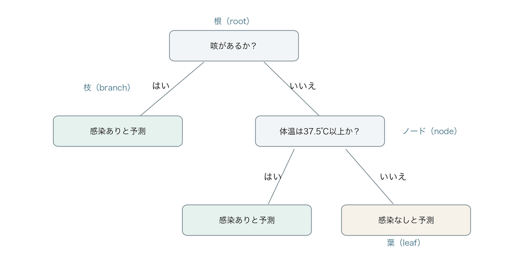

たとえば、咳がなく、体温が38.0℃なら、最初に「いいえ」、次に「はい」と進み、「感染ありと予測」に到着する。出発点を**根（root）**、質問や結果の場所を**ノード（node）**、その間の道を**枝（branch）**、最後に予測を返す場所を**葉（leaf）**という。

この例では質問と37.5℃という境界を人が決めた。一方、機械学習の決定木では、過去のデータを使い、どの特徴量で、どこを境に分けるかを決めていく。どの質問を選ぶか、また質問を増やしすぎないようにするにはどうすればよいかを、次の章で考える。

注：樹形図は、複雑な場合分けを整理するのに役立つ。統計学入門のベイズの定理でも使ったので、忘れた人は復習しておこう。

# 2 タイタニック号の生存確率を考える

タイタニック号は、1912年の初航海中に北大西洋で氷山と衝突し、沈没した客船である。多くの乗客と乗員が犠牲となった。この事故を題材にした映画『タイタニック』（1997年）は、アカデミー賞で作品賞を含む11部門を受賞した。この事故を題材に、乗客の情報から生存・死亡を予測するKaggleのコンペティション [Titanic - Machine Learning from Disaster](https://www.kaggle.com/competitions/titanic) は、機械学習の入門課題としてよく知られている。この講義では、コンペティションの訓練用データを使い、決定木の仕組みを考える。

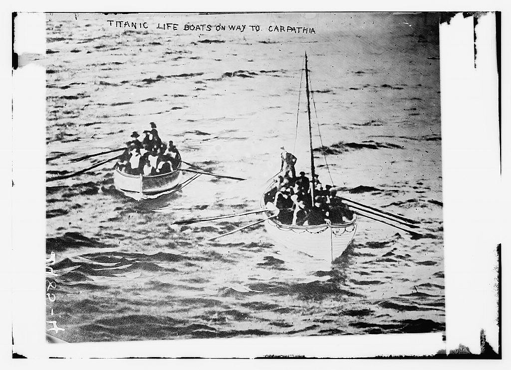

救助船カルパチア号に向かう救命ボート（1912年4月）。Bain News Service、米国議会図書館所蔵。

乗客の情報から、生存したかどうかを予測しよう。事故や災害では、置かれた状況や救助の順序によって、生存の可能性が人によって異なることがある。タイタニック号では、救命ボートに女性や子どもを優先するよう指示されたという証言がある。そこで、**性別、年齢、客室等級**は予測に役立つ特徴量 $X$ の候補になる。

たとえば、三等客室の女性の生存を予測してみよう。下の図では、まず①性別を聞き、女性には②次に客室等級を聞く。分けられたグループの生存割合は、学習データから計算したものである。最初に何を聞くかによって、次の質問を考えるグループの人数や構成が変わり、予測の結果も変わることがある。

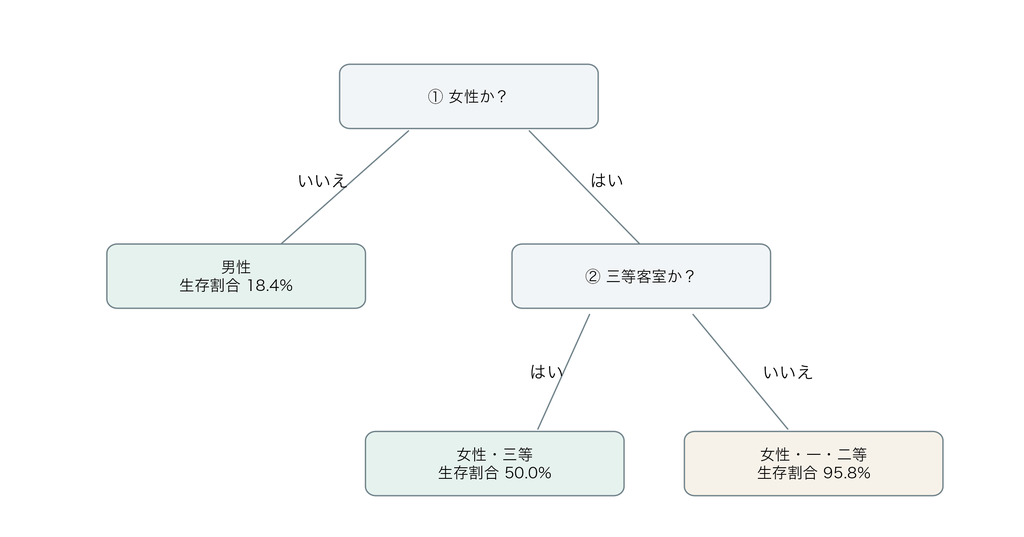

決定木は、質問が上手な記者に似ている。いくつかの質問を重ねることで、予測に役立つ情報を引き出せる。しかし、質問の内容や順番が適切でなければ、予測の性能が悪くなることもある。

予測には、乗船時に分かる情報を使う。事故後に判明する救命ボートの情報などを使うと、予測時に知りえない情報が入り、**情報漏洩（data leakage）**が起こる。事後の情報を使うと、予測性能を実際より高く見積もる。

## 2.1 男女別で見る生存率

まず、質問を一つしかできない場合を考えよう。「女性か」と尋ね、学習データの男女それぞれについて、何人が生存したかを見てみよう。

名簿上の性別は女性か？

いいえ（男性）

**死亡と予測**451人のうち83人が生存  
生存割合 18.4%

はい（女性）

**生存と予測**261人のうち196人が生存  
生存割合 75.1%

性別だけが分かっている場合、女性は「生存」、男性は「死亡」と予測するのが自然である。女性の生存割合は 75.1%、男性は 18.4% であり、女性のほうが 56.7 ポイント高い。女性では生存、男性では死亡がそれぞれ多数派だからである。

全員が出発する場所を**根（root）**、質問で分かれた先を**ノード（node）**、それ以上質問せずに予測を返す場所を**葉（leaf）**という。

## 2.2 客室等級から見る生存率

次に、男女それぞれについて、客室等級によって生存割合がどう違うかを見てみよう。表1は、同じ学習データの乗客を性別と客室等級ごとにまとめたものである。

表1 生存者数／死亡者数（生存割合）

| 客室等級 | 女性 | 男性 |
| --- | --- | --- |
| 一等 | 78 ／ 1（98.7%） | 35 ／ 62（36.1%） |
| 二等 | 59 ／ 5（92.2%） | 10 ／ 72（12.2%） |
| 三等 | 59 ／ 59（50.0%） | 38 ／ 234（14.0%） |

女性も男性も、客室等級によって生存割合が異なる。たとえば、女性の一等と三等を比べると、三等の生存割合はかなり低い。女性の生存を予測するときに、客室等級は有効な指標の一つであることがわかる。男性では、一等と二等の生存割合に差があるが、その差は女性の一等と三等の差ほど大きくない。

あなたなら、**どんな質問をどの順番で聞く**だろうか。

# 3 質問の選び方

第2章では、「女性か」→「三等客室か」の順番で質問したが、「三等客室か」→「女性か」の順番でも質問できる。どちらの質問を先に使うと、予測しやすくなるだろうか。

分けた後に、生存者が多いグループと死亡者が多いグループに分かれれば、それぞれで多数派を予測できる。そこで、各グループに生存と死亡がどのくらい混ざっているかは、質問を比べるための有効な指標となる。

## 3.1 ジニ不純度で測る

たとえば、全員が生存したグループでは、結果は混ざっていない。一方、生存と死亡が半々のグループでは、二つの結果が混ざっている。この混ざり具合を数値で表す方法の一つが**ジニ不純度（Gini impurity）**である。

一般に、あるグループの結果が $K$ 個のクラスに分かれ、クラス $k$ の割合が $p_k$ のとき、ジニ不純度 $G$ は次の式で求められる。

$$G=1-\sum_{k=1}^{K}p_k^2. \tag{1}$$

今回は予測する結果が「生存」と「死亡」の二つなので、$K=2$ である。生存割合を $p$ とすると、死亡割合は $1-p$ となり、式(1)は次のようになる。

$$G=1-p^2-(1-p)^2. \tag{2}$$

二つのクラスを扱う場合、ジニ不純度の範囲は $0\leq G\leq 0.5$ である。全員が生存または全員が死亡なら $G=0$、生存と死亡が半々なら $G=0.5$ となる。値が小さいほど混ざり具合が小さい。なお、$K$ クラスの場合、割合がすべて等しいときに $G$ は最大値 $1-1/K$ をとる。

生存割合を動かして、不純度がどう変わるか確かめよう。

生存割合を動かす

## 3.2 分岐前と分岐後を比較

「女性か」と「三等客室か」の二つを、最初の質問の候補として比べよう。どちらも、質問前の同じ学習データ 712 人を使う。生存は 279 人、死亡は 433 人なので、質問前の不純度 $G_{\mathrm{pre}}$ は次の通りである。

$$G_{\mathrm{pre}}=1-\left(\frac{279}{712}\right)^2-\left(\frac{433}{712}\right)^2\approx
0.4766.$$

二つのシナリオを、それぞれ質問前の全員から始めよう。下の図では、質問の答えごとに分けた人数と、各グループの不純度を示す。

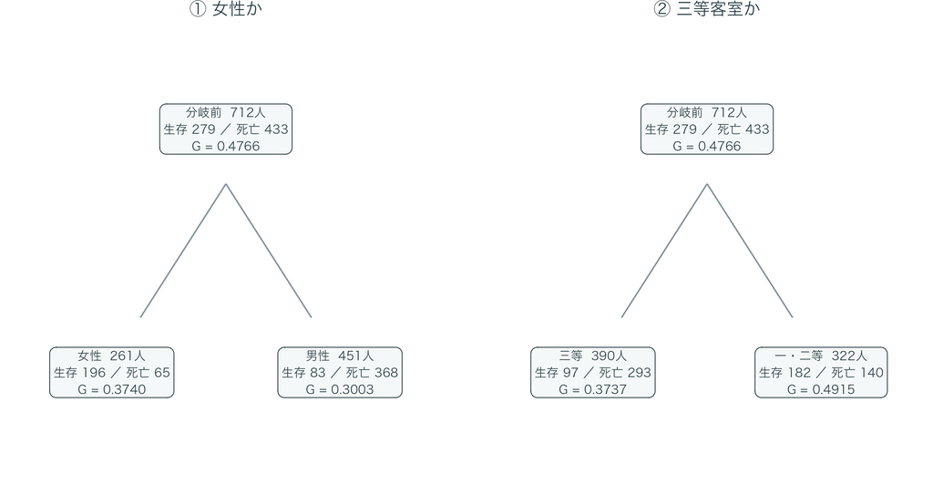

分岐後は二つのグループになり、それぞれに不純度がある。分岐前の不純度と比べるために、加重平均で分岐後の平均的な不純度を求める。

### 3.2.1 分岐後の不純度を求める

分岐後の不純度は、各グループの人数の割合を重みとして求める。

$$G_{\mathrm{post}}=\frac{n_1}{n}G_1+\frac{n_2}{n}G_2,
\qquad n=n_1+n_2.$$

ここで、$n$ は合計人数、$n_1$ と $n_2$ はそれぞれ第1・第2グループの人数、$G_1$ と $G_2$ はそれぞれの不純度である。$G_{\mathrm{post}}$ は分岐後の加重平均である。

① 「女性か」で分ける場合

女性と男性の人数と不純度を、それぞれ式に入れる。

$$G_{\mathrm{post}}'=\frac{261}{712}\times
0.3740+\frac{451}{712}\times 0.3003\approx 0.3274.$$

② 「三等客室か」で分ける場合

三等と一・二等についても、同じように計算する。

$$G_{\mathrm{post}}''=\frac{390}{712}\times
0.3737+\frac{322}{712}\times 0.4915\approx 0.4270.$$

### 3.2.2 分岐前と分岐後の不純度を比べる

分岐後の不純度を、共通の分岐前の値と比べる。不純度の減少量 $\Delta G$ は次のように求める。

$$\Delta G = G_{\mathrm{pre}} - G_{\mathrm{post}}.$$

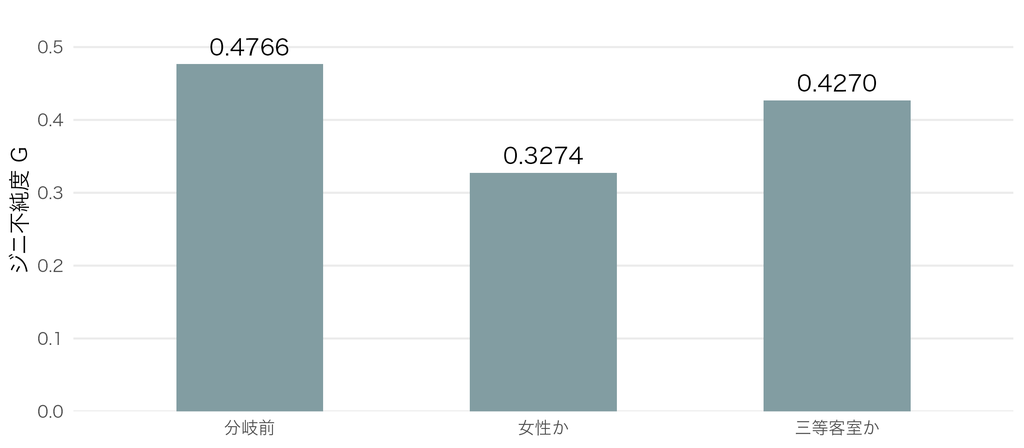

| 状態 | 不純度 | 分岐前からの減少量 |
| --- | --- | --- |
| 分岐前 | 0.4766 | — |
| 分岐後① 女性か | 0.3274 | 0.1493 |
| 分岐後② 三等客室か | 0.4270 | 0.0496 |

この二つの質問では、最初に「女性か」と聞くほうが不純度の減少量が大きいため、生存と死亡の混ざり具合をより小さくできる。

今回扱う **CART（Classification and Regression Trees）**では、候補となる質問を比べ、不純度の減少量が最も大きい質問を選ぶ。どの質問でも、乗客を二つのグループに分け、分岐前と分岐後の不純度を比べる。

| 特徴量の種類 | 例 | 二つに分ける質問の例 |
| --- | --- | --- |
| 三つ以上のカテゴリ | 客室等級 | 「一等か」「二等か」「三等か」 |
| 連続変数 | 年齢 | 「20歳未満か」「30歳未満か」 |

三つ以上のカテゴリを持つ変数や連続変数も、このように「はい／いいえ」で答えられる二値分岐を作ることで、決定木の学習に使うことができる。

## 3.3 二つ目以降の質問

最初の質問「女性か」で、乗客は女性と男性に分かれた。次は**女性のグループ**について、客室等級を使ってもう一度分けよう。男性はこの計算に含めない。最初の質問と同じように、分岐前と分岐後の不純度を比べ、減少量が大きい質問を選ぶ。

特徴量を列に並べた特徴行列を $X=[\boldsymbol{x}_1,\boldsymbol{x}_2,\ldots,\boldsymbol{x}_d]$ とする。各列は一つの特徴量を表し、$d$ は特徴量の数である。 各特徴量から「はい／いいえ」で分ける質問を作り、不純度の減少量が最も大きい質問を選ぶ。分かれたグループごとに同じ手順を繰り返す。同じ特徴量を異なる条件で再び使うこともできる。

「女性だけ」を選び、「一等か」「二等か」「三等か」を比べてみよう。分岐前と分岐後の不純度を比較し、質問を決めることができる。

質問を聞く相手 質問

**はい（三等）**

**いいえ（一・二等）**

女性のグループでは、三つの質問の中で「三等か」で分岐した場合に、不純度の減少量が最も大きい。このように、分けたグループごとに次の質問を選び、分岐を繰り返すことを**再帰的分割**という。

データを分け、各グループで同じ手順を繰り返すのは、**分割統治（divide and conquer）**の考え方である。大きな問題を小さく分け、それぞれで予測を作る。また、各段階で不純度を最も減らす質問を選ぶ方法を**貪欲法（greedy algorithm）**という。その時点で最もよい質問を選ぶため、木全体が最適になるとは限らない。

## 3.4 決定木はどのように予測するか

学習した決定木で新しい乗客を予測するときは、その乗客の情報を使って質問に答え、根から葉まで進む。そして、たどり着いた葉の**学習データ**を使って予測する。つまり、過去のデータのうち、同じ葉に入る乗客の生存割合を使って、新しい乗客の生存を予測する。

生存か死亡かを予測するには、ロジスティック回帰と同じように、乗客 $i$ の生存の予測確率 $\hat p_i$ を**閾値** $t$ と比べる。生存を1、死亡を0とすると、予測クラス $\hat y_i$ は次のようになる。

$$\hat y_i=\begin{cases}
1 & (\hat p_i\geq t)\\
0 & (\hat p_i<t)
\end{cases}$$

k-NNは近くのデータの多数派を使うのに対し、決定木は質問をたどって到着した葉のデータを使う。どちらも、学習データから新しいデータの結果を予測する。

## 3.5 剪定（pruning）

次の図は、質問を繰り返して枝が増えた木である。

[figure not shown]

線形回帰では、特徴量や多項式の項を増やすほど、予測性能がよくなるとは限らない。モデルが複雑になりすぎると、学習データに合いすぎて、テストデータでの予測が悪くなることがある。これを**過学習（overfitting）**という。

決定木でも同じように、特徴量や質問を増やせば、必ず予測性能がよくなるわけではない。分岐を繰り返して木が複雑になると、少人数にたまたま現れたノイズまで学習し、学習データではうまく予測できても、テストデータでは誤差が大きくなることがある。

成長させた木から枝を取り除き、より単純な木にする操作を**剪定（pruning）**という。枝を残すと学習データへの当てはまりはよくなるが、木は複雑になる。剪定では、枝を残すことで得られる改善と、木の複雑さを比べ、改善が小さい枝から取り除く。

剪定は、回帰で学んだ Lasso と同じように、モデルが複雑になりすぎないようにする方法である。

|  | Lasso | 決定木の剪定 |
| --- | --- | --- |
| 複雑さを抑える方法 | 係数を小さくし、一部を0にする | 枝を取り除く |
| 調整する値 | $\lambda$ | `cp` |

剪定では、枝を残した場合と取り除いた場合を比べ、予測の改善が木を複雑にするだけの価値があるかを考える。木が複雑になっても学習データへの当てはまりが十分に改善しなければ、枝を取り除く。`cp` は、この複雑さに対する基準を調整する。

Lasso と同じように、剪定の強さを調整する `cp` は分析者が設定する。しかし、どの値が最適かは事前には分からない。そこで、いくつかの候補について交差検証を行い、それぞれの正解率を比較する。

たとえば、次のような結果が得られたとしよう。数値は説明のための仮の例である。

| `cp` | 交差検証の平均正解率 |
| --- | --- |
| 0.001 | 78.0% |
| 0.005 | 80.5% |
| 0.01 | 81.0% |
| 0.05 | 77.5% |

この例では、平均正解率が最も高い `cp = 0.01` を選ぶ。

`cp`（complexity parameter）を変えて、同じ学習データから作った木がどう変わるか見てみよう。`cp` が大きくなるほど、木の構造はシンプルになる。

cp

● 分岐 ● 葉

注：剪定処理の詳細は専門的であり、この講義の範囲を超えるため省略する。興味のある人は、以下の文献を参照してほしい。

参考文献：Esposito, F., Malerba, D., & Semeraro, G. (1997). A comparative analysis of methods for pruning decision trees. *IEEE Transactions on Pattern Analysis and Machine Intelligence, 19*(5), 476–491. https://doi.org/10.1109/34.589207

## 3.6 パラメーターとハイパーパラメーター

決定木では、分岐のルールや葉の予測値が学習データから決まる。ここでは、これらを学習するパラメーターとして考える。一方、学習前に設定する条件がハイパーパラメーターである。

| 種類 | 内容 | 決め方 |
| --- | --- | --- |
| パラメーター | 質問に使う特徴量と分け方 | 学習データから決める |
| パラメーター | 各葉の予測値 （生存割合など） | 学習データから求める |
| ハイパーパラメーター | `cp`：剪定の強さ | 今回は交差検証で選ぶ |
| 分類の閾値 | $t$ | 予測確率をクラスに変換する閾値。 ハイパーパラメータとして扱える |
| ハイパーパラメーター | `maxdepth`： 深さの上限 `minsplit`： 分岐を試す最小人数 `minbucket`： 葉の最小人数 | 今回は固定 |

分類の閾値 $t$ は、予測確率をクラスに変える基準であり、木の構造は変えない。閾値を調整する場合は、学習データ内の交差検証で候補を比較できる。

決定木の構造を調整するハイパーパラメーターには、`cp` のほかにも `maxdepth`、`minsplit`、`minbucket` などがある。この講義では簡単のためにこの三つを固定するが、実務では交差検証で選ぶこともできる。後で学ぶ Random Forest や XGBoost でも、木の複雑さを調整する似た考え方が登場する。この講義では、まず `cp` による木の複雑さの調整を中心に理解しよう。

線形回帰は、一つの式で全体の関係を表し、係数を推定する。一方、決定木は、分岐の条件と葉の予測で関係を表す。

# 4 Rでタイタニック号の乗客の生存を予測する

まず、実習に使うパッケージを読み込む。

```r
# 初回のみ：install.packages(c("rpart.plot", "gmodels"))
library(caret)
library(rpart)
library(rpart.plot)
library(gmodels)
library(ggplot2)
```

## 4.1 データの読み込みと前処理

Kaggleの `train.csv` は、生存・死亡が記録された891人分のデータである。コンペティションの `test.csv` には正解が含まれないため、この講義では使用せず、`train.csv` を改めて学習用と検証用に分ける。

講義のプロジェクトフォルダからCSVを読み込み、実習に使う列だけを残して先頭の6行を確認する。

```r
passengers <- read.csv("data/titanic/train.csv")
passengers <- passengers[c("Survived", "Sex", "Pclass", "Age")]
head(passengers)
```

|  | Survived | Sex | Pclass | Age |
| --- | --- | --- | --- | --- |
| 1 | 0 | male | 3 | 22 |
| 2 | 1 | female | 1 | 38 |
| 3 | 1 | female | 3 | 26 |
| 4 | 1 | female | 1 | 35 |
| 5 | 0 | male | 3 | 35 |
| 6 | 0 | male | 3 | NA |

実習に使う変数は次のとおりである。

| 変数名 | 内容 |
| --- | --- |
| `Survived` | 生存・死亡（0：死亡、1：生存） |
| `Sex` | 性別 |
| `Pclass` | 客室等級（1等・2等・3等） |
| `Age` | 年齢 |

列名を小文字に変換し、`pclass` と `sex` を因子にする。目的変数 `survived` も因子にし、分類問題として扱う。

```r
# 列名を小文字に統一する
names(passengers) <- tolower(names(passengers))

# 目的変数とカテゴリ変数を因子にする
passengers$survived <- factor(passengers$survived, levels = c(0, 1),
                              labels = c("Lost", "Survived"))
passengers$pclass <- factor(passengers$pclass, levels = 1:3)
passengers$sex <- factor(passengers$sex)

# 生存予測に使う特徴量を指定する
predictors <- c("sex", "pclass", "age")
```

この実習では、性別（`sex`）、客室等級（`pclass`）、年齢（`age`）の3項目を使う。

## 4.2 学習データと検証データ

乗客の約80%を学習用の `ship_train`、残りの約20%を検証用の `ship_validation` とする。検証用データは正解を含み、決定木とその設定を選び終えた後の評価に使う。

```r
# データの分割
set.seed(2026)
train_id <- sample(seq_len(nrow(passengers)), size = floor(0.8 * nrow(passengers)))
ship_train <- passengers[train_id, ]
ship_validation <- passengers[-train_id, ]

table(ship_train$survived)
```

```
##
##     Lost Survived
##      433      279
```

学習データでは、死亡が 433 人、生存が 279 人である。

```r
colSums(is.na(ship_train[predictors]))
```

```
##    sex pclass    age
##      0      0    147
```

学習用 712 人のうち 147 人は、年齢が欠損になっている。データ数が限られるため、年齢を安易に補完すると実際の値と大きく異なる場合がある。ここでは年齢を補完せず、この乗客たちも残して学習する。欠損値は `rpart` の代理分岐を使って扱う。

**代理分岐**とは、質問に必要な値が欠損しているとき、似た分け方になる別の質問で進む枝を決める方法である。例えば、年齢が分からない場合、仮に「客室等級が1等か」という質問が年齢による分け方に似ていれば、その質問を代わりに使う。似ているかどうかはデータで調べるため、この質問が必ず選ばれるわけではない。代理分岐は年齢を補完せず、進む枝を決める。使える代理分岐がない場合は、人数の多い側に進む。

## 4.3 木の複雑さを設定する

学習を始める前に、木をどこまで複雑にしてよいかを決める。`rpart.control()` には、先ほど説明したハイパーパラメーターを指定する。

| 設定 | 役割 | 今回の値 |
| --- | --- | --- |
| `cp` | 大きいほど、質問を減らす | `0`（デフォルト：`0.01`） |
| `maxdepth` | 続けて質問できる回数の上限 | `10`（デフォルト：`30`） |
| `minsplit` | さらに分けるために必要な人数 | `20`（デフォルト：`20`） |
| `minbucket` | 分けた後の各グループの最小人数 | `7`（デフォルト：`7`） |

`minbucket` を指定しない場合は、`minsplit` の3分の1を四捨五入した人数になる。`minsplit = 20` なら7人である。`maxdepth` を小さくしたり、`minsplit` や `minbucket` を大きくしたりすると、細かい分岐が作られにくくなる。今回はまず剪定前の木を調べるため、`cp = 0` とする。この場合も、深さや人数の条件に従って成長が止まる。後で交差検証を使い、`cp` を選ぶ。詳細は[Rのマニュアル](https://stat.ethz.ch/R-manual/R-devel/library/rpart/html/rpart.control.html)を読んでください。

設定を一つずつ変え、調整前後の木の形を比べてみよう。

`cp`0 大きくすると、質問の数が少なくなる

`maxdepth`10 質問を何回まで続けてよいか

`minsplit`20 この人数に満たないグループは、もう分けない

`minbucket`7 分けた後の各グループに、最低限必要な人数

調整前

調整後

**●** 分岐**■** 葉

複雑さへのペナルティを強くしすぎると、最初から分岐できず、枝や葉が増えないことになる。これでは、剪定前後の木の違いを比べられない。そこで、まず `cp = 0` として木を大きめに育て、その後で剪定を考える。以下の設定を初期値とする。

```r
# 木の複雑さと欠損値の扱いを設定する
tree_control <- rpart.control(
  cp = 0, maxdepth = 10, minsplit = 20, minbucket = 7,
  usesurrogate = 2, xval = 0
)
```

`usesurrogate = 2` は、欠損値があるときに代理分岐を使い、使える代理分岐がなければ人数が多い側に進む設定である。`xval = 0` は `rpart()` 内部の交差検証を行わない設定である。後で、これまで使ってきた `caret` を使い、各 `cp` を共通の5分割で比較する。

## 4.4 決定木の学習

先ほどの設定を `control` に渡し、`rpart()` で分類木を学習する。回帰分析の `lm()` と同じく、式の左側に目的変数、右側に特徴量を置き、`data` に学習データを指定する。`method = "class"` は分類木、`parms = list(split = "gini")` はジニ不純度で分け方を選ぶ指定である。

```r
# 分類木を学習する
large_tree <- rpart(
  survived ~ sex + pclass + age, data = ship_train, method = "class",
  parms = list(split = "gini"), control = tree_control
)
```

`large_tree` に学習済みの木が保存される。ここには、選ばれた分岐の条件、各ノードの人数、予測するクラスとその確率などが入っている。

補足：分類木では、エントロピー（`parms = list(split = "information")`）も使える。数値を予測する回帰木は `method = "anova"` とし、`parms` は指定しない。二乗誤差の合計（SSE）で分け、RMSEなどで予測を評価する。

回帰分析で学習済みモデルを表示したり `summary()` を使ったりしたように、決定木も学習結果を確認できる。まず、`print()` で木全体の分岐と各ノードの予測を表示する。

```r
print(large_tree, digits = 3)
```

```
## n= 712
##
## node), split, n, loss, yval, (yprob)
##       * denotes terminal node
##
##   1) root 712 279 Lost (0.6081 0.3919)
##     2) sex=male 451  83 Lost (0.8160 0.1840)
##       4) age>=5.5 432  70 Lost (0.8380 0.1620)
##         8) pclass=2,3 337  37 Lost (0.8902 0.1098) *
##         9) pclass=1 95  33 Lost (0.6526 0.3474)
##          18) age>=53 19   2 Lost (0.8947 0.1053) *
##          19) age< 53 76  31 Lost (0.5921 0.4079)
##            38) age< 47.5 66  24 Lost (0.6364 0.3636)
##              76) age>=43 11   1 Lost (0.9091 0.0909) *
##              77) age< 43 55  23 Lost (0.5818 0.4182)
##               154) age>=27.5 42  15 Lost (0.6429 0.3571)
##                 308) age< 34 8   2 Lost (0.7500 0.2500) *
##                 309) age>=34 34  13 Lost (0.6176 0.3824)
##                   618) age>=37.5 9   4 Lost (0.5556 0.4444) *
##                   619) age< 37.5 9   3 Survived (0.3333 0.6667) *
##               155) age< 27.5 13   5 Survived (0.3846 0.6154) *
##            39) age>=47.5 10   3 Survived (0.3000 0.7000) *
##       5) age< 5.5 19   6 Survived (0.3158 0.6842) *
##     3) sex=female 261  65 Survived (0.2490 0.7510)
##       6) pclass=3 118  59 Lost (0.5000 0.5000)
##        12) age>=38.5 11   1 Lost (0.9091 0.0909) *
##        13) age< 38.5 107  49 Survived (0.4579 0.5421)
##          26) age>=5.5 97  46 Survived (0.4742 0.5258)
##            52) age< 12 7   0 Lost (1.0000 0.0000) *
##            53) age>=12 90  39 Survived (0.4333 0.5667)
##             106) age>=27.5 14   6 Lost (0.5714 0.4286) *
##             107) age< 27.5 76  31 Survived (0.4079 0.5921) *
##          27) age< 5.5 10   3 Survived (0.3000 0.7000) *
##       7) pclass=1,2 143   6 Survived (0.0420 0.9580) *
```

例えば最後の `7) pclass=1,2` は、上の `sex=female` に続く「女性で1等または2等」のグループである。人数は 143 人、予測は `Survived` で、全員を生存と予測すると 6 人が外れる。括弧内は死亡・生存の割合（約 4.2%、95.8%）、`*` はここで分け終わる印である。

`summary()` では、分け方や各グループの人数・生存割合を詳しく確認できる。各分岐点では分け方の候補を比べ、不純度を最も減らすものを選んでいる。回帰分析のような係数やp値は表示されない。

**summary() の出力を見る**

```r
summary(large_tree)
```

```
## Call:
## rpart(formula = survived ~ sex + pclass + age, data = ship_train,
##     method = "class", parms = list(split = "gini"), control = tree_control)
##   n= 712
##
##            CP nsplit rel error
## 1 0.469534050      0 1.0000000
## 2 0.025089606      1 0.5304659
## 3 0.016129032      2 0.5053763
## 4 0.012544803      4 0.4731183
## 5 0.007168459      6 0.4480287
## 6 0.004778973      7 0.4408602
## 7 0.000000000     14 0.3942652
##
## Variable importance
##    sex pclass    age
##     63     21     16
##
## Node number 1: 712 observations,    complexity param=0.4695341
##   predicted class=Lost      expected loss=0.3918539  P(node) =1
##     class counts:   433   279
##    probabilities: 0.608 0.392
##   left son=2 (451 obs) right son=3 (261 obs)
##   Primary splits:
##       sex    splits as  RL,       improve=106.270900, (0 missing)
##       pclass splits as  RRL,      improve= 35.335920, (0 missing)
##       age    < 5.5  to the right, improve=  7.298106, (147 missing)
##
## Node number 2: 451 observations,    complexity param=0.02508961
##   predicted class=Lost      expected loss=0.1840355  P(node) =0.633427
##     class counts:   368    83
##    probabilities: 0.816 0.184
##   left son=4 (432 obs) right son=5 (19 obs)
##   Primary splits:
##       age    < 5.5  to the right, improve=9.153725, (98 missing)
##       pclass splits as  RLL,      improve=7.724792, (0 missing)
##
## Node number 3: 261 observations,    complexity param=0.01612903
##   predicted class=Survived  expected loss=0.2490421  P(node) =0.366573
##     class counts:    65   196
```

[output cut: 154 more lines]

```
##     class counts:    21    13
##    probabilities: 0.618 0.382
##   left son=618 (9 obs) right son=619 (9 obs), 16 observations remain
##   Primary splits:
##       age < 37.5 to the right, improve=0.4444444, (16 missing)
##
## Node number 618: 9 observations
##   predicted class=Lost      expected loss=0.4444444  P(node) =0.01264045
##     class counts:     5     4
##    probabilities: 0.556 0.444
##
## Node number 619: 9 observations
##   predicted class=Survived  expected loss=0.3333333  P(node) =0.01264045
##     class counts:     3     6
##    probabilities: 0.333 0.667
```

`Variable importance` は、特徴量が木の分岐にどれだけ役立ったかをまとめた指標である。回帰係数のように、影響の向きや「1単位増えたときの変化」を表すものではない。各ノードでは `class counts` が死亡・生存の人数、`probabilities` がその割合、`Primary splits` が分岐の候補、`Surrogate splits` が代理分岐を示す。

冒頭の表の `nsplit` は分岐の数、`rel error` は根だけで予測した場合を1とした学習データの誤分類の大きさである。これは交差検証の正解率ではない。今回は `xval = 0` なので、この出力に交差検証の誤差は含まれない。

モデルの複雑さを確認するため、葉の数を数えてみよう。

```r
# 葉の数を確認する
large_leaves <- sum(large_tree$frame$var == "<leaf>")
large_leaves
```

```
## [1] 15
```

出来上がった木には 15 個の葉がある。`rpart.plot()` で樹形図を可視化できる。Yesであれば左、Noであれば右に進む。箱の数字は死亡・生存の人数で、青は死亡が多く、緑は生存が多いグループである。

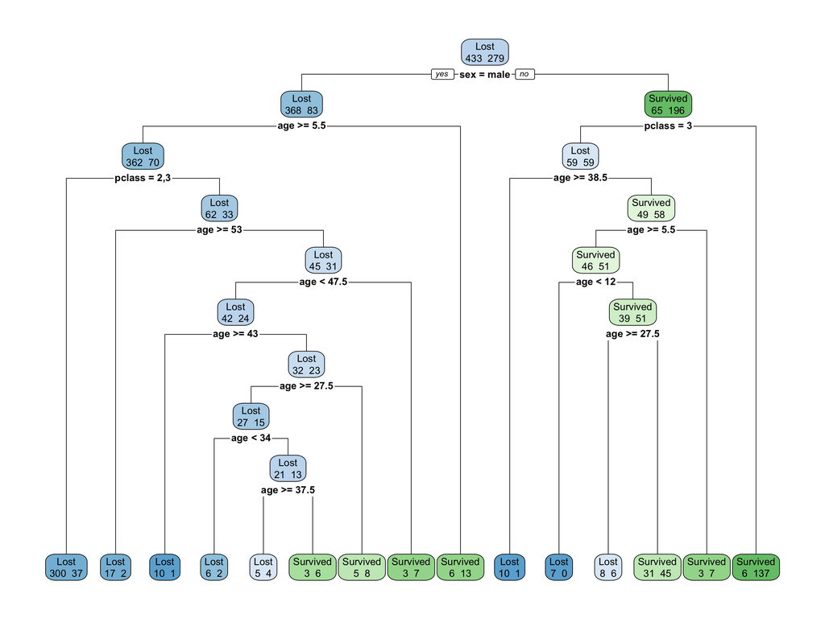

```r
# 樹形図の可視化
# extra = 1：死亡・生存の人数を表示する
# roundint = FALSE：年齢の境目を整数に丸めない
# digits = 3：数値を有効数字3桁で表示する
rpart.plot(large_tree, extra = 1, roundint = FALSE, digits = 3)
```

例えば、30歳・2等の男性を考えよう。図では「男性 → 5.5歳以上 → 2・3等」と左へ進み、死亡300人・生存37人の葉に到着する。生存確率は **37 ÷ (300 + 37) ≈ 11.0%** と予測できる。

## 4.5 交差検証でcpを選ぶ

`cp` を変えて交差検証を行い、平均正解率（Accuracy）が最も高い値を選ぶ。`cp = 0` は大きな木を許し、`cp = 1` は分岐しない木になる。`cp` のデフォルトは `0.01` である。

```r
# 交差検証の設定
set.seed(2026)
folds <- createFolds(ship_train$survived, k = 5, returnTrain = TRUE)
cv_control <- trainControl(
  method = "cv", number = 5, index = folds, selectionFunction = "best"
)
# cpの候補：0〜0.05を0.005刻みで作り、比較用に0.3と1を加える
cp_grid <- data.frame(cp = c(seq(0, 0.05, by = 0.005), 0.3, 1))
```

1回の検証では、四つのfoldを使って質問と分割点を学び、各 `cp` で剪定した木を、残る一つのfoldの乗客に当てる。検証に使うfoldを順に交代すれば、全員について本人の結果を使わずに作った木から予測が得られる。各 `cp` 候補値の五つの正解率の平均を比べる。

`train()` の `x` に特徴量の表、`y` に生存・死亡の因子を渡す。この書き方で客室等級と性別を因子のまま、年齢の欠損も残したまま渡せる。ここで使う `caret` の `rpart` では、平均正解率が完全に同じなら、大きい `cp` が先に選ばれる。

```r
# 交差検証でcpを選ぶ
tree_cv <- train(
  x = ship_train[predictors], y = ship_train$survived,
  method = "rpart", metric = "Accuracy", tuneGrid = cp_grid,
  trControl = cv_control, control = tree_control,
  parms = list(split = "gini")
)
cv_result <- tree_cv$results
best_cp <- tree_cv$bestTune$cp
```

```r
# 交差検証の結果を表示する
knitr::kable(cv_result[c("cp", "Accuracy")])
```

| cp | Accuracy |
| --- | --- |
| 0.000 | 0.7907614 |
| 0.005 | 0.7935586 |
| 0.010 | 0.7907318 |
| 0.015 | 0.7907121 |
| 0.020 | 0.7836895 |
| 0.025 | 0.7850980 |
| 0.030 | 0.7865065 |
| 0.035 | 0.7865065 |
| 0.040 | 0.7921403 |
| 0.045 | 0.7921403 |
| 0.050 | 0.7921403 |
| 0.300 | 0.7921403 |
| 1.000 | 0.6081454 |

大きな木を許した `cp = 0` の平均正解率は 79.08%、根だけの `cp = 1` では 60.81% である。この候補表では `cp` に 0.005 が選ばれる。異なる強さで剪定しても、同じ枝が残ることがある。木が複雑なほど予測がよくなるとは限らない。

## 4.6 剪定前後の予測の比較

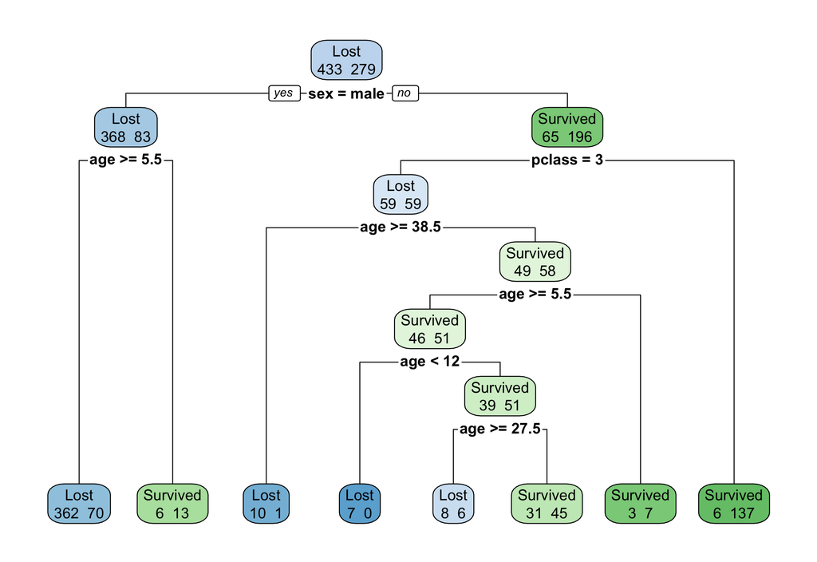

```r
# 剪定後の木
rpart.plot(tree_cv$finalModel, extra = 1, roundint = FALSE, digits = 3)
```

男性は死亡者が多く、細かく分けても「死亡」という予測が変わらないグループが多い。予測の改善が複雑さに見合わない枝は剪定され、男性側は5.5歳で分けるだけの形になった。

年齢・性別・客室等級ごとの生存確率を、剪定前後で比べよう。

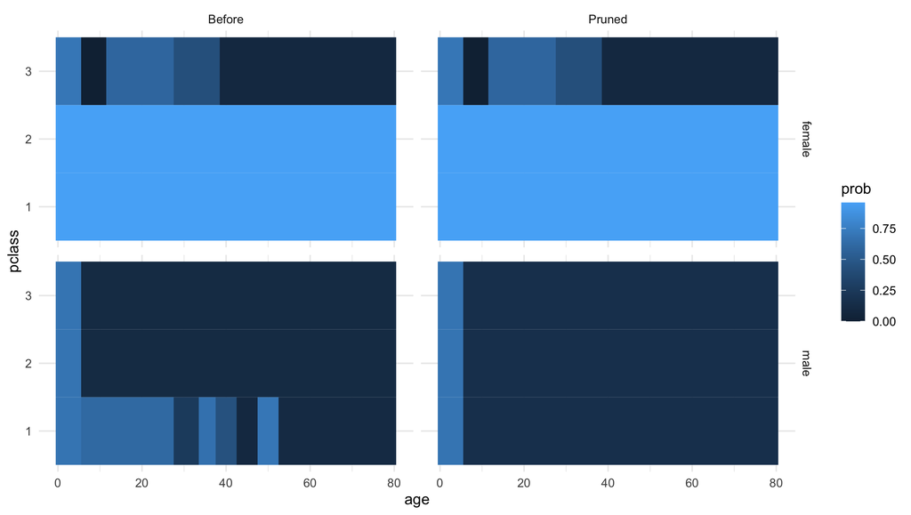

```r
# 性別・等級と年齢の組み合わせを作る
conditions <- expand.grid(
  age = 0:80,
  pclass = levels(ship_train$pclass),
  sex = levels(ship_train$sex)
)

# 剪定前後の生存確率を求める
before <- conditions
after <- conditions
before$prob <- predict(large_tree, conditions, type = "prob")[, "Survived"]
after$prob <- predict(tree_cv, conditions, type = "prob")[, "Survived"]
before$model <- "Before"
after$model <- "Pruned"
predictions <- rbind(before, after)

# 性別と剪定前後に分けて描く
ggplot(predictions, aes(x = age, y = pclass, fill = prob)) +
  geom_tile() +
  facet_grid(sex ~ model) +
  theme_minimal()
```

色が明るいほど生存確率が高い。女性の1・2等は高いままだが、剪定後は男性1等の細かな年齢差がまとめられている。

## 4.7 決定木の評価

最初にデータを、学習用の `ship_train`（712 人）と検証用の `ship_validation`（179 人）に分けた。木の学習と `cp` の選択には学習用データだけを使った。ここでは、正解を含む同じ検証用データで剪定前後の予測を比べる。`CrossTable()` の行が実際の結果、列が予測で、各セルに人数と行の割合を表示する。

まず、剪定前の木で予測する。

```r
# 剪定前の木で検証データを予測する
pred_before <- predict(large_tree, ship_validation, type = "class")
CrossTable(ship_validation$survived, pred_before,
           dnn = c("Actual", "Predicted"),
           prop.r = TRUE, prop.c = FALSE, prop.t = FALSE, prop.chisq = FALSE)
```

```
##
##
##    Cell Contents
## |-------------------------|
## |                       N |
## |           N / Row Total |
## |-------------------------|
##
##
## Total Observations in Table:  179
##
##
##              | Predicted
##       Actual |      Lost |  Survived | Row Total |
## -------------|-----------|-----------|-----------|
##         Lost |        97 |        19 |       116 |
##              |     0.836 |     0.164 |     0.648 |
## -------------|-----------|-----------|-----------|
##     Survived |        21 |        42 |        63 |
##              |     0.333 |     0.667 |     0.352 |
## -------------|-----------|-----------|-----------|
## Column Total |       118 |        61 |       179 |
## -------------|-----------|-----------|-----------|
##
##
```

```r
# 全体の正解率を求める
mean(pred_before == ship_validation$survived)
```

```
## [1] 0.7765363
```

次に、交差検証で選んだ `cp` で剪定した木を使う。

```r
# 剪定後の木で同じ検証データを予測する
pred_after <- predict(tree_cv, ship_validation)
CrossTable(ship_validation$survived, pred_after,
           dnn = c("Actual", "Predicted"),
           prop.r = TRUE, prop.c = FALSE, prop.t = FALSE, prop.chisq = FALSE)
```

```
##
##
##    Cell Contents
## |-------------------------|
## |                       N |
## |           N / Row Total |
## |-------------------------|
##
##
## Total Observations in Table:  179
##
##
##              | Predicted
##       Actual |      Lost |  Survived | Row Total |
## -------------|-----------|-----------|-----------|
##         Lost |       103 |        13 |       116 |
##              |     0.888 |     0.112 |     0.648 |
## -------------|-----------|-----------|-----------|
##     Survived |        26 |        37 |        63 |
##              |     0.413 |     0.587 |     0.352 |
## -------------|-----------|-----------|-----------|
## Column Total |       129 |        50 |       179 |
## -------------|-----------|-----------|-----------|
##
##
```

```r
# 全体の正解率を求める
mean(pred_after == ship_validation$survived)
```

```
## [1] 0.7821229
```

検証データの正解率は、剪定前が約77.7%、剪定後が約78.2%となった。一方、生存者を正しく見つけた割合である再現率（recall）は、約66.7%から約58.7%へ下がった。正解率が高くても、見逃しが少ないとは限らない。

生存者の見逃しを減らしたいなら、交差検証で正解率だけでなく再現率も比べ、`cp` を選ぶ。また、生存と判断する確率の基準を0.5より下げる方法もある。ただし、死亡者を生存と誤って予測することも増えやすいため、両方の誤りを確認する。

正解が公開されていない `test.csv` は各自で予測し、結果をKaggleに提出してスコアを確認してください（手順は省略）。

# 5 まとめ

決定木は、質問でグループを分け、葉の人数や割合から予測する。今回の分類木ではジニ不純度で質問を選んだ。木が複雑なほど予測がよくなるとは限らないため、交差検証で `cp` を選び、剪定によって複雑さを調整した。線形回帰やRidge・Lasso、Logistic回帰が一組の係数で関係を表すのに対し、決定木は分岐の条件と葉の予測で表すため、樹形図で確認する。

**どの特徴量 $X$ を使うかも重要**である。実習では説明のため3項目に絞ったが、氏名（`Name`）の `Miss` や `Mrs` から婚姻状況を推測できる。こうした情報を特徴量にし、予測に役立つかを確かめることもできる。

剪定後は正解率が少し上がった一方、生存者の再現率は下がった。`CrossTable()` で誤分類の内訳も確認しよう。実習の誤りは実際の判断に影響しないが、犯罪捜査やがんの検出では、無関係な人を疑う誤りや病気の見逃しが重大な結果につながるため、それぞれの影響を考える必要がある。Kaggleの[Titanic](https://www.kaggle.com/competitions/titanic/overview/evaluation)では正解率（Accuracy）で評価されるが、単一の指標だけでモデルの有用性を判断するのは危険である。

# 6 課題

**To-do**

1. **ClassmojiでHW2のリポジトリを開く**  
   https://app.classmoji.io/
2. **課題に取り組み、GitHubにpushする**  
   課題の内容と提出物は、リポジトリの `README.md` を確認すること。  
   提出方法はR入門のサイトの下方を参照すること。  
   https://ztempest0218.github.io/R-Programming/

**HW2 マーケティングへの反応の予測**

**締切：2026年12月2日（水）16:30（日本時間）**